# Homework 2: Linear regression

2022-10-12

## PSTAT 231

## Matias Strehl

Let’s start loading the libraries we will use.

```r
rm(list=ls())
# Load libraries
# install.packages("yardstick")
library(yardstick)
library(tidyverse)
library(tidymodels)
library(ggplot2)
library(magrittr)
```

## Read the data set

```r
# Read data set
abalone <- read_csv("abalone.csv")
```

## Question 1

In the next graph we observe a histogram with the distribution of age, with a vertical straight line right at the mean. We observe that most observations accumulate around 10, and that the distribution is right-skewed. From our calculations we observe that the average age is 11.43, while the standard deviation is 3.22.

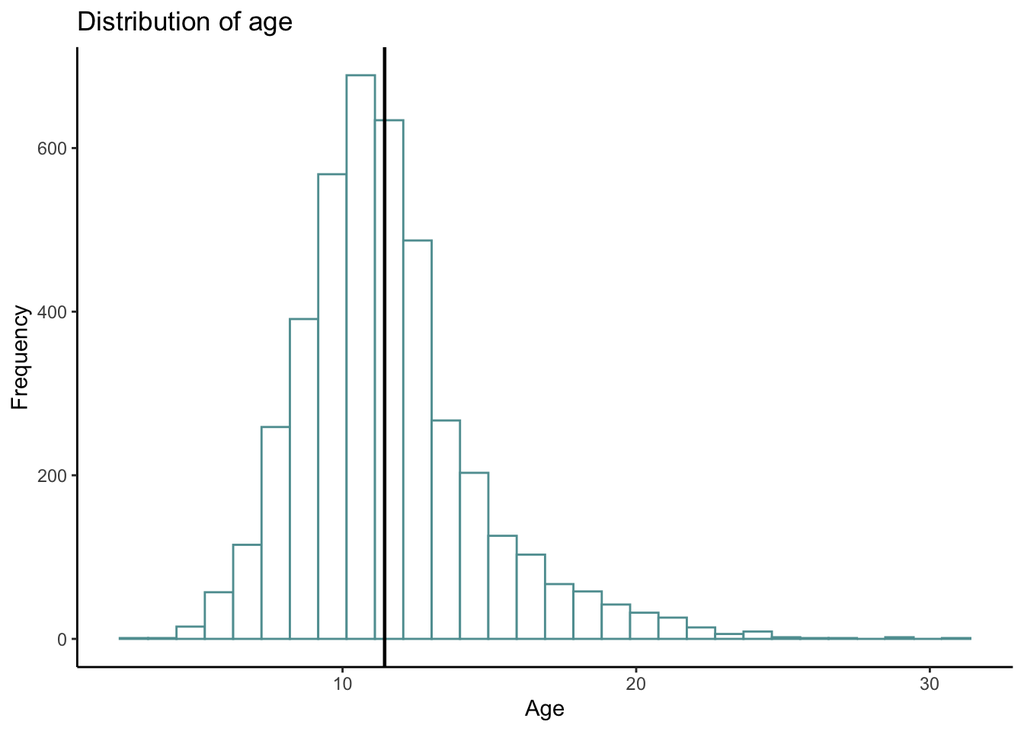

```r
# Creating age variable
abalone <- abalone %>%
  mutate(age = rings + 1.5)

# We drop rings variable since we won't use it
abalone <- abalone %>%
  select(-rings)

ggplot(data = abalone, aes(x = age)) +
  geom_histogram(color = "cadetblue", fill = "white")+
  labs(
    title="Distribution of age",
    x = "Age",
    y = "Frequency") +
  geom_vline(aes(xintercept = mean(age)),
                 size = 0.8)  +
  theme_classic()
```

```r
abalone %>%
  summarize(mean = mean(age), sd = sd(age))
```

```
## # A tibble: 1 × 2
##    mean    sd
##   <dbl> <dbl>
## 1  11.4  3.22
```

## Question 2

```r
# Split the data
set.seed(1701)

abalone_split <- initial_split(abalone, prop = 0.80, strata = age)
abalone_train <- training(abalone_split)
abalone_test <- testing(abalone_split)
```

## Question 3

```r
# Create recipe
abalone_recipe <- recipe(age ~ . , data = abalone_train ) %>%
  step_dummy(all_nominal_predictors()) %>%
  step_interact(terms = ~ type_M:shucked_weight) %>%
  step_interact(terms = ~ longest_shell:diameter) %>%
  step_interact(terms = ~ shucked_weight:shell_weight)  %>%
  step_center(all_predictors()) %>%
  step_scale(all_predictors())
```

We don’t include the variable *rings* as a predictor because is perfectly correlated with our outcome *age*. Besides, the whole idea of this exercise is to predict the age of the abalone without using data about the number of rings, so there is no need to kill the abalone to learn about its age.

## Question 4

```r
# Set a linear regression engine
lm_model <- linear_reg() %>%
  set_engine("lm")
```

## Question 5

```r
# Set up an empty workflow, add model, add recipe
lm_wflow <- workflow() %>%
  add_model(lm_model) %>%
  add_recipe(abalone_recipe)
```

## Question 6

In the table below we can see the results of our linear regression in the training set.

```r
# Fit the linear model to the training set
lm_fit <- fit(lm_wflow, abalone_train)

lm_fit %>%
  # This returns the parsnip object:
  extract_fit_parsnip() %>%
  # Now tidy the linear model object:
  tidy()
```

```
## # A tibble: 13 × 5
##    term                          estimate std.error statistic  p.value
##    <chr>                            <dbl>     <dbl>     <dbl>    <dbl>
##  1 (Intercept)                    11.4       0.0372   307.    0
##  2 longest_shell                   0.891     0.280      3.19  1.45e- 3
##  3 diameter                        2.35      0.305      7.71  1.66e-14
##  4 height                          0.295     0.0697     4.24  2.31e- 5
##  5 whole_weight                    4.98      0.396     12.6   1.64e-35
##  6 shucked_weight                 -4.05      0.243    -16.7   2.96e-60
##  7 viscera_weight                 -0.917     0.157     -5.84  5.87e- 9
##  8 shell_weight                    1.68      0.211      7.95  2.62e-15
##  9 type_I                         -0.386     0.0581    -6.65  3.35e-11
## 10 type_M                         -0.0930    0.0958    -0.970 3.32e- 1
## 11 type_M_x_shucked_weight         0.121     0.100      1.21  2.26e- 1
## 12 longest_shell_x_diameter       -3.33      0.390     -8.54  1.93e-17
## 13 shucked_weight_x_shell_weight  -0.341     0.198     -1.72  8.57e- 2
```

Now, we can predict the requested value.

```r
abalone_train_res_1 <- predict(lm_fit, new_data = data.frame(
  type = "I" , longest_shell = 0.5, diameter = 0.1,
  height = 0.3, whole_weight = 4, shucked_weight = 1,
  viscera_weight = 2, shell_weight = 1))

abalone_train_res_1
```

```
## # A tibble: 1 × 1
##   .pred
##   <dbl>
## 1  22.6
```

As we can see, the predicted age for an abalone with the requested features is 22.59.

## Question 7

```r
# Assessing our model
# Create a metric set
abalone_metrics <- metric_set(rmse,rsq,mae)

# Predict values with our model
abalone_train_res_2 <- predict(lm_fit, new_data = abalone_train %>%
                               select(-age))

# Add the actual age column
abalone_train_res_2 <- bind_cols(abalone_train_res_2, abalone_train %>%
                                   select(age))

# Apply our metric set
abalone_metrics(abalone_train_res_2, truth = age,
                estimate = .pred)
```

```
## # A tibble: 3 × 3
##   .metric .estimator .estimate
##   <chr>   <chr>          <dbl>
## 1 rmse    standard       2.15
## 2 rsq     standard       0.559
## 3 mae     standard       1.56
```

From the table above we can see that $R^{2} = 0.56$, $RMSE = 2.15$ and $MAE = 1.56$.

We can also plot our estimated values against the true values of age to assess our model.

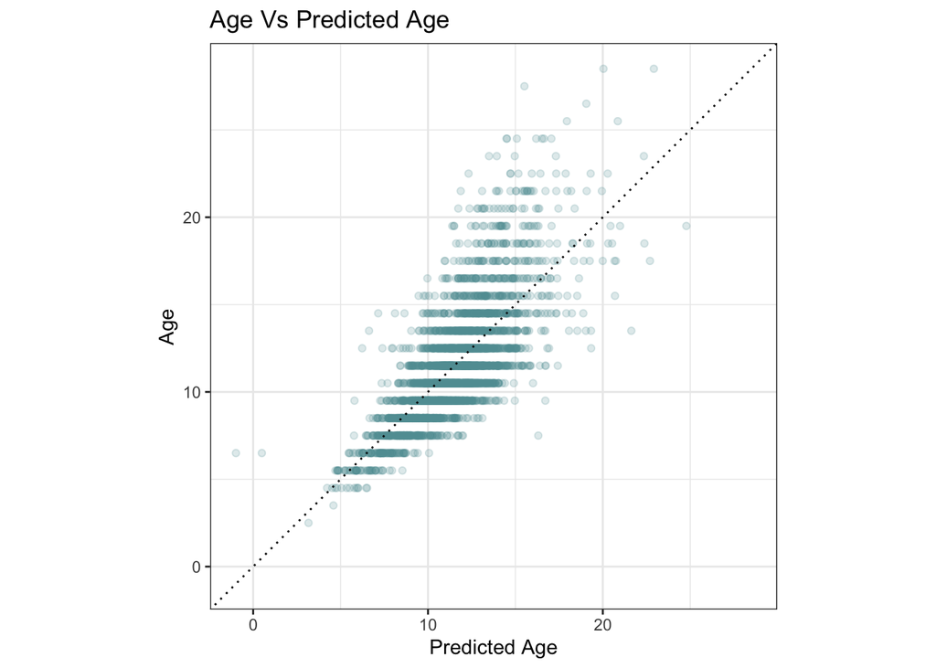

```r
# Plot
abalone_train_res_2 %>%
  ggplot(aes(x = .pred, y = age)) +
  labs(title = "Age Vs Predicted Age",
       x = "Predicted Age",
       y = "Age") +
  geom_point(alpha = 0.2, col = "cadetblue") +
  geom_abline(lty = 3) +
  theme_bw() +
  coord_obs_pred()
```

From the graph we observe that our model does a pretty good job approximately for age values below 15, but the model tends to underestimate the true value of age for age values above 15.

# Only 231 students

In lecture, we presented the general bias-variance tradeoff, which takes the form:

$[(y_0 - \hat{f}(x_0))^2] = Var(\hat{f}(x_0)) + [Bias(\hat{f}(x_0)) ]^2 + Var(\epsilon)$

## Question 8

**Which term(s) in the bias-variance tradeoff above represent the reproducible error? Which term(s) represent the irreducible error?**

The $Var(\hat{f}(x_{0})) + [Bias(\hat{f}(x_{0}))]^{2}$ term on the right hand size of the equation represents the reproducible error, while the $Var(\epsilon)$ term represents the irreducible error.

## Question 9

**Using the bias-variance tradeoff above, demonstrate that the expected test error is always at least as large as the irreducible error.**

From the lecture, we know that the best that we can have is $\hat{f}(x_{0}) = E[Y|X=x_{0}]$, that is, our estimation for the conditional mean of $Y$ given $X=X_0$ is exactly equal to the conditional expectation. In that case, we have that $E[(\hat{f}(x_{0}) - E(\hat{f}(x_0)))^{2}] = [E[\hat{f}(x_0)] - f(x_0)]^{2} = 0$, that is, the two first terms of the right hand size (RHS) of the equation are equal to zero. However, we will always have the $Var(\epsilon)$ term in the expected test error, which is positive. Therefore, we have that $E[(y_0 - \hat{f}(x_0))^{2}] \geq Var(\epsilon)$, that is, the expected test error is always greater or equal than the irreducible error. A different way of seeing it is that the first two terms of the RHS of the equation are always greater or equal than zero, so the expected test error is always greater or equal than $Var(\epsilon)$

## Question 10

**Prove the bias-variance trade-off.**

We start plugging in $y$.

$$E[(y-\hat{f}(x))^2] = E[(f(x) + \epsilon
-\hat{f}(x))^2]$$
Expanding the square:

$$E[(y-\hat{f}(x))^2] = E[(f(x)
-\hat{f}(x))^2] + 2E[\epsilon(f(x) - \hat{f}(x))] +
E[\epsilon^2]$$
Note that the term in the middle is equal to zero since $\epsilon$ is random noise. Since $E[\epsilon] = 0$ we have that that $E[\epsilon^2] = Var(\epsilon)$. Then,

$$E[(y-\hat{f}(x))^2] = E[(f(x)
-\hat{f}(x))^2] + Var(\epsilon)$$
To finish the proof, we need to prove that the first term on the RHS of the equation is equal to $Var(\hat{f}(x_0)) + [Bias(\hat{f}(x_0))]^2$.

By adding and substracting,

$$E[(f(x) -\hat{f}(x))^2] = E[(f(x) -
E(\hat{f}(x)) + E(\hat{f}(x)) -\hat{f}(x))^2]$$

Comnbining terms,

$$E[(f(x)-\hat{f}(x))^2] = E[( [f(x) -
E(\hat{f}(x))] - [ \hat{f}(x) - E(\hat{f}(x))])^2]$$
Expanding the squares and using linearity of expectations

$$E[(f-\hat{f}(x))^2] = E[(f(x) -
E(\hat{f}(x)))^2] + E[(\hat{f}(x) -E(\hat{f}(x)))^2] +2E[ (f(x) -
E(\hat{f}(x))) (\hat{f}(x) - E(\hat{f}(x)))]$$

Because the third term is zero, we have:

$$E[(f(x)-\hat{f}(x))^2] =
E(Bias(\hat{f}(x))^2) + Var(\hat{f}(x))$$
Which is equivalent to:
$$E[(f(x)-\hat{f}(x))^2] =
Bias(\hat{f}(x))^2 + Var(\hat{f}(x))$$

so the proof is completed.